# Лабораторная работа № 10

Презентация

Гайдук Софья Сергеевна

1032253645@rudn.ru

Российский университет дружбы народов

2026-04-15

## Title

# Информация

## Докладчик

- Гайдук Софья Сергеевна
- студент
- Российский университет дружбы народов им. П. Лумумбы
- 1032253645@rudn.ru
- https://github.com/SofiaGayduk/study_2025-2026_os-intro

## Цель работы

Познакомиться с операционной системой Linux. Получить практические навыки работы с редактором vi, установленным по умолчанию практически во всех дистрибутивах.

## Выполнение лабораторной работы

## Задание 1. Создание нового файла с использованием vi

Создадим каталог с именем ~/work/os/lab10. Перейдем во вновь созданный каталог (рис. 1).

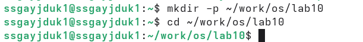

Figure 1: image1

[figure not shown]

Figure 2: image2

## Задание 1. Создание нового файла с использованием vi

Нажмем клавишу i и вводем следующий текст. После нажмем клавишу Esc для перехода в командный режим после завершения ввода текста (рис. 3).

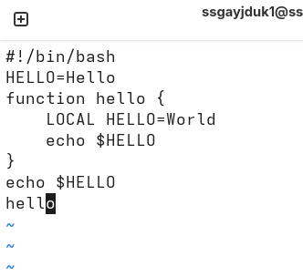

Figure 3: image3

## Задание 2. Редактирование существующего файла

Установим курсор в конец слова HELL второй строки. Перейдем в режим вставки и заменим на HELLO. Нажмем Esc для возврата в командный режим (рис. 7).

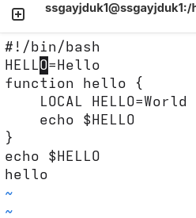

Figure 7: image7

## Задание 2. Редактирование существующего файла

Установим курсор на четвертую строку и сотрем слово LOCAL. Перейдем в режим вставки и наберем следующий текст: local, нажмем Esc для возврата в командный режим (рис. 8).

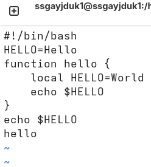

Figure 8: image8

## Задание 2. Редактирование существующего файла

Установим курсор на последней строке файла. Вставим после неё строку, содержащую следующий текст: echo $HELLO (рис. 9).

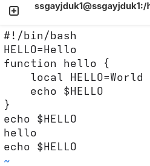

Figure 9: image9

## Задание 2. Редактирование существующего файла

Удалим последнюю строку (рис. 10).

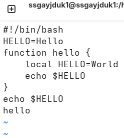

Figure 10: image10

## Задание 2. Редактирование существующего файла

Введем команду отмены изменений u для отмены последней команды (рис. 11).

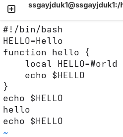

Figure 11: image11

## Выводы

Мы познакомились с операционной системой Linux. Получили практические навыки работы с редактором vi, установленным по умолчанию практически во всех дистрибутивах.

## Список литературы

1.Kulyabov. Лабораторная работа № 10. Текстовой редактор vi. RUDN